# Practical Machine Learning Assignment

Edie Hawthorne

9/13/2018

## Summary

This project is to use data from accelerometers on the belt, forearm, arm, and dumbell of 6 participants. They were asked to perform barbell lifts correctly and incorrectly in 5 different ways. Then we will analyze their data to quantify how well they do it by using the best fit prediction model to predicte the manner in which they did the exercise.

Exactly according to the specification (Class A), throwing the elbows to the front (Class B), lifting the dumbbell only halfway (Class C), lowering the dumbbell only halfway (Class D) and throwing the hips to the front (Class E).

## Loading the training and testing data sets

```r
library(caret)
library(e1071)
library(ggplot2)
library(Hmisc)
library(dplyr)
library(splines)
library(glmnet)
library(randomForest)
library(rattle)
library(csv)
library(kernlab)
library(corrplot)

training_df <- read.csv("~/Coursera Files/Practical Machine Learning/training.csv")

testing_df <- read.csv("~/Coursera Files/Practical Machine Learning/testing.csv")
```

## Cross Validation on Training Data set

```r
inTrain_nt <- createDataPartition(y=training_df$classe, p=0.75, list=FALSE)
training_train <- training_df[inTrain_nt,]
training_val <- training_df[-inTrain_nt,]
```

## Plotting Predictors for visualiztion

Plot the training data set (training_train_new2) from the training dataframe(training_df) to analyze the corelation of the predictors. After analyzing the data and the plots, I decided to only use 13 predictors (pitch_belt, roll_arm, pitch_arm, yaw_arm, total_accel_arm, roll_dumbbell, pitch_dumbbell, yaw_dumbbell, total_accel_dumbbell, roll_forearm, pitch_forearm, yaw_forearm, total_accel_forearm) to build my models.

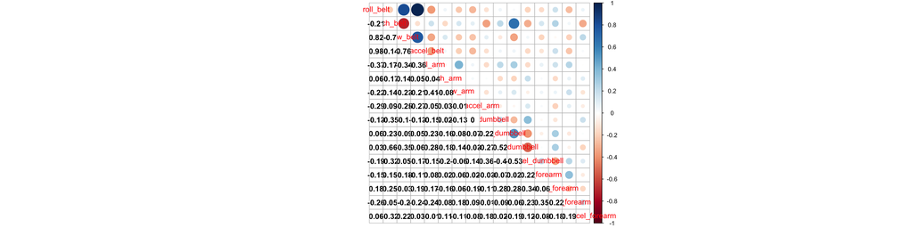

## PreProcessing - Standarlizing

By looking at the historygram of the “roll_forearm” variable, I try to standarlize the roll_forearm variable, and build a model called modelFit_stand based on the standarlized variables.

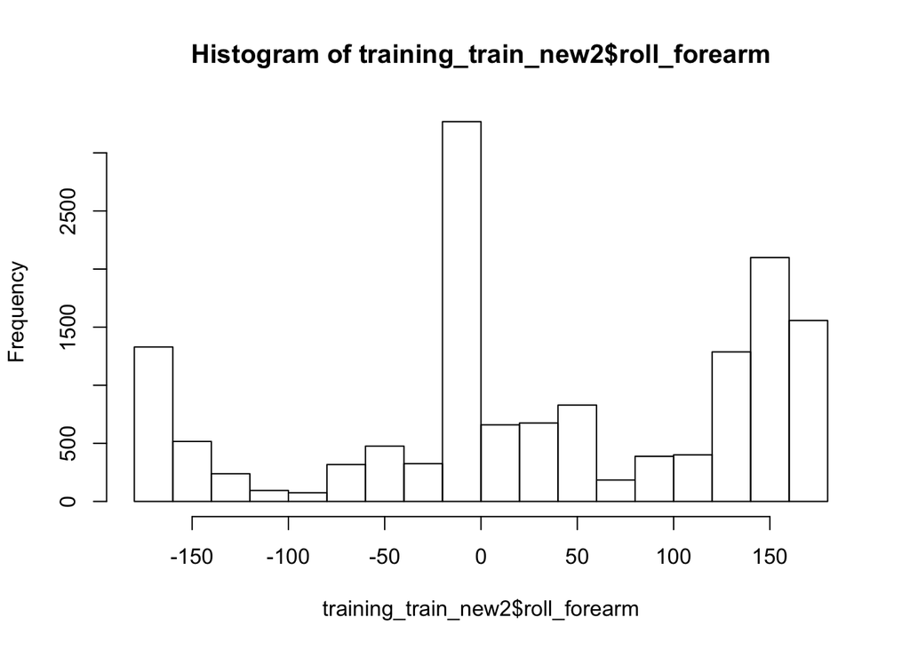

## Bridge Regression and Lasso Regression

Build bridge regression and lasso regression models called ridge.mod and lasso.mod. And predict the “classe” variable based on these two models.

## Preprocessing with PCA

Processing with PCA to reduce the number of predictors. Then build 3 PCA models using different methods (random forrest, rpart and gbm).

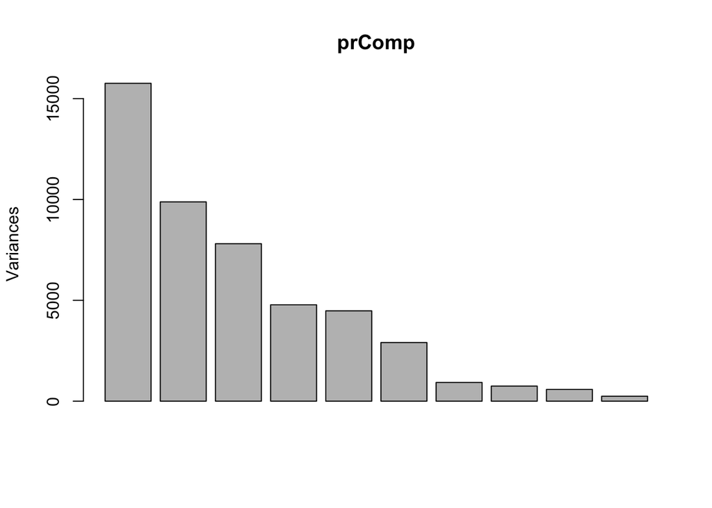

## Decision Trees (Classification Trees)

Analyze with Decision Trees and build a model based on the analysis called modFit_ct.

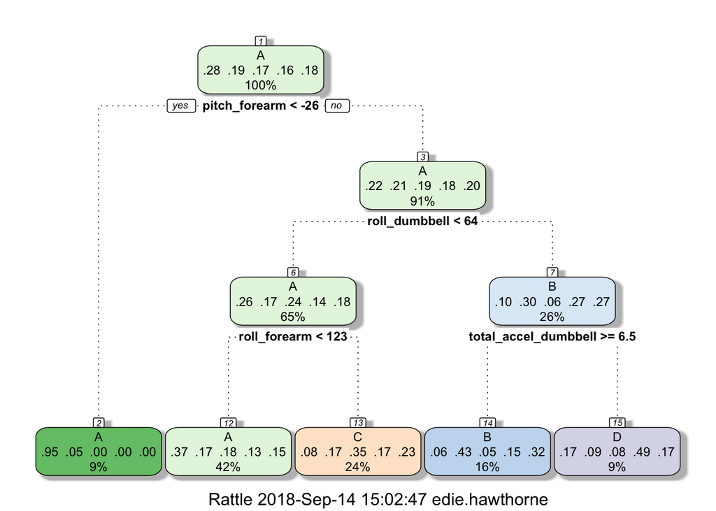

## Predict New Values

```
Call:
 randomForest(formula = classe ~ ., data = training_train_new2,      method = "rf", verbose = FALSE)
               Type of random forest: classification
                     Number of trees: 500
No. of variables tried at each split: 3

        OOB estimate of  error rate: 2.15%
Confusion matrix:
     A    B    C    D    E class.error
A 4166   11    2    2    4 0.004540024
B   58 2714   47   13   16 0.047050562
C    1   25 2510   30    1 0.022204908
D    2    1   46 2358    5 0.022388060
E    4   11   20   17 2654 0.019216556
```

```
Confusion Matrix and Statistics

          Reference
Prediction    A    B    C    D    E
         A 1388   20    0    0    0
         B    6  904   10    0    3
         C    0   17  831   11    6
         D    0    4   12  792    7
         E    1    4    2    1  885

Overall Statistics

               Accuracy : 0.9788
                 95% CI : (0.9744, 0.9826)
    No Information Rate : 0.2845
    P-Value [Acc > NIR] : < 2.2e-16

                  Kappa : 0.9732
 Mcnemar's Test P-Value : NA

Statistics by Class:

                     Class: A Class: B Class: C Class: D Class: E
Sensitivity            0.9950   0.9526   0.9719   0.9851   0.9822
Specificity            0.9943   0.9952   0.9916   0.9944   0.9980
Pos Pred Value         0.9858   0.9794   0.9607   0.9718   0.9910
Neg Pred Value         0.9980   0.9887   0.9941   0.9971   0.9960
Prevalence             0.2845   0.1935   0.1743   0.1639   0.1837
Detection Rate         0.2830   0.1843   0.1695   0.1615   0.1805
Detection Prevalence   0.2871   0.1882   0.1764   0.1662   0.1821
Balanced Accuracy      0.9946   0.9739   0.9818   0.9897   0.9901
```

## Fit the best model

Then we use our best fit Random Forest Model to predict the participants’ movements in the testing_df_new dataset to see how well they were performing.

```r
pred_bestmd <- predict(modFit_rf, newdata=testing_df_new, type="class")
pred_bestmd
```

```
##  1  2  3  4  5  6  7  8  9 10 11 12 13 14 15 16 17 18 19 20
##  B  A  B  A  A  E  C  B  A  A  B  C  B  A  E  E  A  B  B  B
## Levels: A B C D E
```